# Regresión

© Ricardo A. Queralt

MSDF: Sesión 1

# Bibliografía

- An Introduction to Statistical Learning with Applications in R.

  Springer

  2013 (Corrected at 7th printing 2017)

  Gareth James • Daniela Witten • Trevor Hastie • Robert Tibshirani

  http://www-bcf.usc.edu/~gareth/ISL/
- R in Action (SECOND EDITION)

  Data analysis and graphics with R

  ROBERT I. KABACOFF

  MANNING

  https://github.com/kabacoff/RiA2
- Practical Data Science with R

  NINA ZUMEL y JOHN MOUNT

  MANNING

  https://github.com/WinVector/zmPDSwR

# Introducción

La regresión es una de las técnicas estadísticas más utilizadas, con la finalidad de predecir una variable dependiente con una o más variables predictivas (Independientes, explicativas o regresores).

En general el análisis de regresión se puede utilizar para:

```
* Identificar las variables explicativas.
* Describir la relación existente entre las variables.
* Predecir la variable dependiente a partir de las variables independientes.
```

El modelo se define como :

$$y_{i}=\beta _{0}+\beta _{1}x_{1i}+\beta _{2}x_{2i}+\cdots +\beta
_{k}x_{ki}+u_{i}\;\;\;\;\;\;i=1\ldots n$$

Donde las variables son:

$$y\equiv endogena, dependiente, a explicar$$
$$X\equiv exogenas, independientes, explicativa$$
$$u\equiv término\ de\ error,\ perturbación$$

Donde $i$ es el dato u observación iésima.

Si expresamos las $n$ ecuaciones del modelo tenemos:

$$\begin{array}{c}
y_{1}=\beta _{0}+\beta _{1}x_{11}+\beta _{2}x_{21}+\cdots +\beta
_{k}x_{k1}+u_{1} \\
y_{2}=\beta _{0}+\beta _{1}x_{12}+\beta _{2}x_{22}+\cdots +\beta
_{k}x_{k2}+u_{2} \\
\cdots \\
y_{n}=\beta _{0}+\beta _{1}x_{1n}+\beta _{2}x_{2n}+\cdots +\beta
_{k}x_{kn}+u_{n}%
\end{array}$$

El modelo se puede expresar en forma matricial. En primer lugar se representan las matrices que contiene los datos:

$$y=\left[
\begin{array}{c}
y_{1} \\
y_{2} \\
\vdots \\
y_{n}%
\end{array}%
\right] _{n\times 1}X=\left[
\begin{array}{cccc}
1 & x_{11} & \ldots & x_{1k} \\
1 & x_{12} & \cdots & x_{2k} \\
\vdots & \vdots & \ddots & \vdots \\
1 & x_{1n} & \cdots & x_{Tk}%
\end{array}%
\right] _{n\times \left( k+1\right) }\beta =\left[
\begin{array}{c}
\beta _{0} \\
\beta _{1} \\
\beta _{2} \\
\vdots \\
\beta _{k}%
\end{array}%
\right] _{\left( k+1\right) \times 1}u=\left[
\begin{array}{c}
u_{1} \\
u_{2} \\
\vdots \\
u_{n}%
\end{array}%
\right] _{n\times 1}$$

Quedando representado de forma reducida por el modelo:

$$y=X\beta +u$$

Siendo cada una de las variables las siguientes matrices, con su correspondiente dimensión:

$$\left[
\begin{array}{c}
y_{1} \\
y_{2} \\
\vdots \\
y_{T}%
\end{array}%
\right] _{n\times 1}=\left[
\begin{array}{cccc}
1 & x_{11} & \ldots & x_{1k} \\
1 & x_{12} & \cdots & x_{2k} \\
\vdots & \vdots & \ddots & \vdots \\
1 & x_{1n} & \cdots & x_{Tk}%
\end{array}%
\right] _{n\times \left( k+1\right) }\left[
\begin{array}{c}
\beta _{0} \\
\beta _{1} \\
\beta _{2} \\
\vdots \\
\beta _{k}%
\end{array}%
\right] _{\left( k+1\right) \times 1}+\left[
\begin{array}{c}
u_{1} \\
u_{2} \\
\vdots \\
u_{n}%
\end{array}%
\right] _{n\times 1}$$

La matriz $X$ se puede representar como $n$ vectores columnas donde cada columna son los datos muestrales de una variable:

$$X=\left[ 1~x_{1}\;x_{2}\;\ldots \;x_{k}\right]$$

#### Ejemplo: Advertising

> En el fichero `Advertising.csv` se encuentran los resultados de 200 campañas de publicidad de una entidad financiera.
> - La variable `Sales` representa el número de productos que han vendido en la campaña en miles (p.e. el número de fondos de inversión, de depósitos o de cuentas corrientes).
> - Las variables `TV`, `Radio` y `Newspaper` los gastos en miles de euros de las respectivas campañas de publicidad.

> Hay importantes preguntas que queremos contestar mediante el modelo de regresión:
> - ¿Hay una relación entre el presupuesto de publicidad y las Ventas?
> - ¿Cómo de fuerte es la relación entre los gastos de publicidad y las ventas?
> - ¿Cuál de los los medios contribuye más a las ventas?
> - ¿Cómo de precisos se pueden estimar los efectos de cada medio sobre las ventas?
> - ¿Cómo de preciso se pueden predecir las ventas futuras?
> - ¿Es la relación lineal?
> - ¿Hay sinergias entre los diferentes tipos de anuncios?

```r
mData=read.csv("./Datos/Advertising.csv")
vY=mData$Sales #Creo la variable dependiente
mX=cbind(1,mData[,2:4]) #Creo la matriz de variables independientes con una columnas de unos para la constante
head(vY) # Muestro el vector Y
```

```
## [1] 22.1 10.4  9.3 18.5 12.9  7.2
```

```r
head.matrix(mX) # Muestro la matriz X
```

```
##   1    TV Radio Newspaper
## 1 1 230.1  37.8      69.2
## 2 1  44.5  39.3      45.1
## 3 1  17.2  45.9      69.3
## 4 1 151.5  41.3      58.5
## 5 1 180.8  10.8      58.4
## 6 1   8.7  48.9      75.0
```

El término regresión es utilizado para nombrar una gran variedad de modelos:

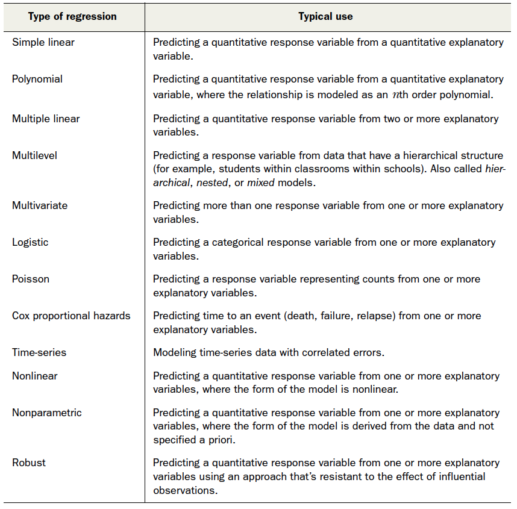

# Supervisado vs No-supervisado

La mayoría de los problemas de predicción pueden clasificarse en supervisados y no-supervisados.

Nos encontramos con problemas supervisados cuando para cada observación de las variables explicativas existe una variable dependiente, se quiere estimar un modelo que relacione las variables explicativas (predictores) con la variable respuesta. (p.e. modelos de regresión)

Sin embargo cuando nos encontramos con un vector de observaciones de las variables pero que no está asociado a una variable respuesta, es un problema no-supervisado. Es imposible estimar un modelo de regresión puesto que no hay variable dependiente que predecir. Estamos en cierto sentido trabajando a ciegas, por lo que nuestro análisis no está supervisado.

# Tipos de Datos

Hay tres tipos de datos que pueden utilizarse en el Data Science aplicado a finanzas:

- Series temporales: Datos de una o varias variables recopilados sobre una periodo de tiempo. Los datos están asociados a frecuencia de observación (diarios, mensuales, anuales,…). 1
- Sección Cruzada: Datos de una o varias variables recopilados sobre diferentes individuos (personas, empresas, países,..) en un mismo instante del tiempo. 2
- Datos de Panel: Datos de una o varias variables recopilados sobre diferentes individuos (personas, empresas, países,..) en diferentes periodos de tiempo.

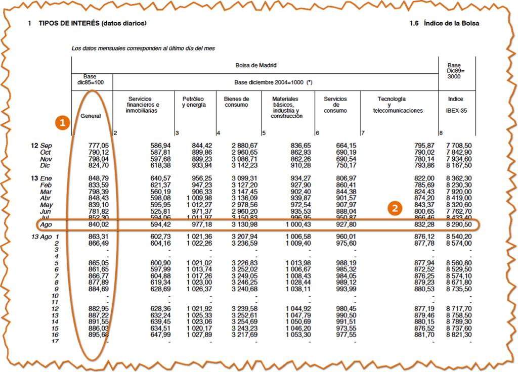

# El modelo: Hipótesis

$$y_i = \beta _1 + \beta _2 \cdot x_{2i}+ \cdots + \beta _k \cdot x_{ki} + u_t \\ i = 1 \cdots n \\$$

Hipótesis:

1 El modelo es correcto: a. Es lineal b. Estas las variables adecuadas. c. No falta ninguna ni sobra.

2 La variable X no es aleatoria

3 El error tiene esperanza cero
$$E\left( {{u_i}} \right) = 0$$

4 Ausencia de Heteroscesdasticidad:
$$E\left( {u_i^2} \right) = \sigma _u^2\,\,\forall i$$
5 Ausencia de Autocorrelación (solamente Series Temporales):
$$E\left( {{u_i},{u_j}} \right) = 0\,\,\forall i \ne j$$
6 Normalidad de los errores:
$${u_i} \sim N\left( {0;\sigma _u^2\,} \right)$$
7 Las hipótesis en forma matricial:
$$E(u) = 0 \\
Var(u) = {\sigma _u}^2 \cdot {I_n} \\
{u_t} \sim N(0;{\sigma _u}^2) \Leftrightarrow u \sim N(0;{\sigma _u}^2 \cdot {I_n}) \\$$

# Estimación de los Coeficientes

El método utilizado es el de Mínimos Cuadrados.

Se minimiza la suma de los cuadrado de los residuos o suma residual:

$${\text{Residuos: }}\hat u = y - \hat y = y - X\hat \beta \\
{\text{Suma Residual (SR):}} \\
SR = SCR = \sum\limits_1^T {{{\hat u}_t}^2} = \hat u'\hat u = y'y - 2y'X\hat \beta + \hat \beta 'X'X\hat \beta \\$$

De tal forma que los $\hat \beta$ son elegidos de tal forma que son los que menos SCR tienen.

El proceso de optimización consiste en calcular la primera derivada e igualarla a cero, obteniendo las ecuaciones normales:

$${\text{Ecuaciones Normales:}} \\
(X'X)\hat \beta = X'y \\$$

Despejando $\hat \beta$de las ecuaciones normales obtenemos los estimadores:

$${\text{Estimador MCO:}} \\
\hat \beta = {(X'X)^{ - 1}}X'y \\$$

El otro parámetro que tenemos que estimar es la varianza de los errores ${\hat \sigma }^2_u$

$${\hat \sigma }^2_u = \frac{{SCR}}{{n - k}} \\$$

La representación gráfica es la siguiente:

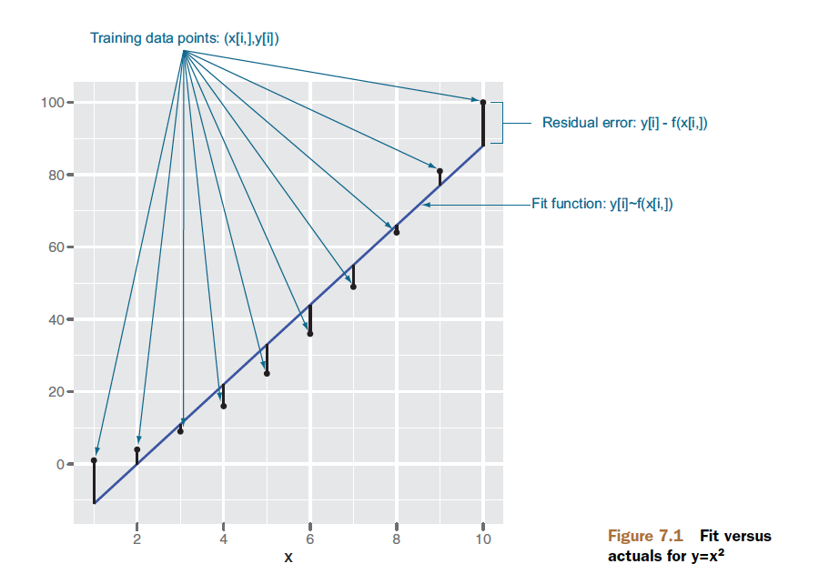

Una vez obtenidos los estimadores es necesario estudiar la precisión de los mismos.

Para ello se calculan las varianzas (matriz de varianzas-covarianzas “VC”" de los estimadores):

$$Var(\hat \beta ) = {\hat \sigma }^2_u{(X'X)^{ - 1}} \\$$
$$Var\left( \hat{\beta}\right) _{K\times K}=\sigma _{u}^{2}\left( X^{\prime
}X\right) ^{-1}=\left(
\begin{array}{cccc}
var\left( \hat{\beta}_{1}\right) & cov\left( \hat{\beta}_{1},\hat{\beta}%
_{2}\right) & \cdots & cov\left( \hat{\beta}_{1},\hat{\beta}_{K}\right) \\
cov\left( \hat{\beta}_{1},\hat{\beta}_{2}\right) & var\left( \hat{\beta}%
_{2}\right) & \cdots & cov\left( \hat{\beta}_{2},\hat{\beta}_{K}\right) \\
\cdots & \cdots & \cdots & \cdots \\
cov\left( \hat{\beta}_{1},\hat{\beta}_{K}\right) & cov\left( \hat{\beta}_{2},%
\hat{\beta}_{K}\right) & \cdots & var\left( \hat{\beta}_{K}\right)%
\end{array}%
\right) _{K\times K}$$
Donde las varianzas de los estimadores (que indican la precisión de la estimación) están en la diagonal de la matriz y las covarianzas entre los estimadores (que indican si hay relación entre los parámetros) se encuentran fuera de la diagonal.

La matriz es simétrica y definida positiva.

Al calcular la raiz cuadrada de la diagonal se obtienen la desviación tipica de los estimadores (errores estandar):

$$dt(\hat \beta _i )=\sqrt{var \left( {{{\hat \beta }_i}} \right)}$$

`Intervalos de Confianza`

Con la desviación típica de los estimadores y el supuesto de normalidad podemos calcular `los intervalos de confianza` para los parámetros desconocidos. (Cuidado!!! los intervalos son para los parámetros desconocidos no de los estimadores).

Se debe determinar inicialmente `el nivel de confianza` del intervalo $1 - \alpha$. Los intervalos serán simétricos, con dos colas y en el centro se encuentra el valor estimado. Será necesario calcular el valor de tablas de la t de student para ${1 - \frac{\alpha }{2}}$. Comprobar como se ha divido por dos el nivel de significación $\alpha$.

$$\hat \beta \pm t_{_{n - k}}^{1 - \frac{\alpha }{2}} \cdot dt(\hat \beta ) \\$$

$$\hat \beta - t_{_{n - k}}^{1 - \frac{\alpha }{2}} \cdot dt(\hat \beta ) \leqslant \beta \leqslant \hat \beta + t_{_{n - k}}^{1 - \frac{\alpha }{2}} \cdot dt(\hat \beta ) \\$$

Para un nivel de confianza del 95% la $t_{_{n - k}}^{1 - \frac{\alpha }{2}}$ toma un valor cercano a 2, siendo el valor del intervalo:

$$\hat \beta \pm 2 \cdot dt(\hat \beta ) \\$$

# Test de hipótesis

`Método de Decisión en Contrastación de Hipótesis`

Con las desviaciones típicas se pueden realizar test de hipótesis sobre los parámetros del modelo.

Las etapas de realización de un test de hipótesis son:

1 Obtener la Muestra.

2 Definir la ${H_0}$ y ${H_1}$ (Hipótesis a contrastar)

3 Calcular el estadístico de contraste (EC) con los datos muestrales.

4 Determinar el nivel de significación.

5 Determinar la Región Crítica (RC)

6 Tomar Decisión: EC incluido en RC entonces H1

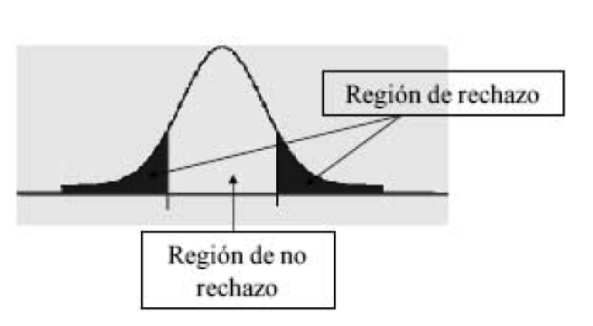

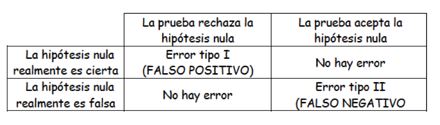

#### Concepto de p-valor

Definimos el p-valor como la probabilidad de que, suponiendo cierta H0, el estadístico de contraste tome un valor al menos tan extremo como el que se obtiene a partir de las observaciones muestrales, i.e., el p-valor es el área de la cola de la distribución (o colas si el test es bilateral) definida a partir del estadístico de contraste:

1. El p-valor sólo puede calcularse una vez tomada la muestra, obteniéndose niveles críticos distintos para cada muestra.
2. El p-valor puede interpretarse como un nivel mínimo de significación en el sentido de que niveles de significación α , iguales o superiores al p - valor llevarán a rechazar la hipótesis nula.

Por tanto, cuanto menor sea el p - valor mayor es el grado de incompatibilidad de la muestra con ${H_0}$, lo que lleva a rechazar ${H_0}$.

Resumiendo:

$$\begin{gathered}
p - valor > \alpha \Rightarrow {H_0} \hfill \\
p - valor < \alpha \Rightarrow {H_1} \hfill \\
\end{gathered}$$

$$\begin{gathered}
{H_0}:\,\,\mu = 0 \hfill \\
{H_1}:\,\,\mu \geqslant 0 \hfill \\
\end{gathered}$$

[figure not shown]

#### Contraste de Significación

El constraste masutilizado es del de significación individual de los coeficentes, que supone:

${H_0}:$ NO hay relación entre la variable ${X_i}$ y la variable $Y$

${H_1}:$ Hay algún tipo de relación entre la variable ${X_i}$ y la variable $Y$

Estadísticamente esta hipótesis es:

${H_0}: \beta_i =0$

${H_1}: \beta_i \ne 0$

Para este contraste se debe calcular el calcular el ratio t:

$$t=\frac{\hat \beta_i - \beta^0_i}{dt(\hat \beta)}$$

donde $\beta^0_i$ es el valor que toma $\beta_i$ si se cumple la hipótesis.

Pero como la hipotesis es que el estimador sea cero, el ratio se calcula como el cociente entre el estimador y su desviación típica:

$$t=\frac{\hat \beta_i}{dt(\hat \beta)}$$

# Ajuste del Modelo

Para analizar el ajuste del modelo se utilizan :

- El error estandar de la regresión.
- El coeficente de determinación $R^2$.
- El estadístico F de contrastación global.

En primer lugar calculamos la relación entre la suma de cuadrado de los residuos con la suma total y la explicada:

$$y = \hat y + \hat u \\
\hat y = X \hat \beta$$

$$\begin{gathered}
SCT = SCE + SCR \hfill \\
SCT = \sum\limits_1^T {{y^2}_t} - T{{\bar y}^2} = y'y - T{{\bar y}^2} \hfill \\
SCE = \sum\limits_1^T {{{\hat y}^2}_t} - T{{\bar y}^2} = \hat \beta 'X'y - T{{\bar y}^2} \hfill \\
SCR = \sum\limits_1^T {{{\hat u}^2}_t} = y'y - \hat \beta 'X'y \hfill \\
\end{gathered}$$

El `error estandar de la regresión` (SER) es el media de la distancia de los valores de $Y$ se desvian de la recta de regresión. Esta medido en las unidades de $Y$.

$$\begin{gathered}
{{\hat \sigma }^2}_u = \frac{{SCR}}{{T - k}} \hfill \\
SER = \sqrt {{{\hat \sigma }^2}_u} = \sqrt {\frac{{SCR}}{{T - k}}} = \sqrt {\frac{{\sum {\hat u_i^2} }}{{T - k}}} \hfill \\
\end{gathered}$$

El $R^2$ o `coeficiente de determinación` es la proporción de la varianza explicada por el modelo (las variables explicativas $X´s$):

$${R^2} = \frac{{SCE}}{{SCT}} = 1 - \frac{{SCR}}{{SCT}}$$

Toma valores entre 0 y 1, suele expresarse en %::

$$0 \leq R^2 \leq 1$$

El $R^2$ aumenta cuando aumentamos el número de regresores. Para evitar este efecto perverso, se calcula el $\bar R^2$ ajustado, que penaliza el $R^2$ con el número de regresores:

$$R^2_a = {{\bar R}^2} = 1 - \left[ {\left( {\frac{{T - 1}}{{T - k}}} \right) \times \left( {1 - {R^2}} \right)} \right] \\
R_a^2 \leqslant {R^2}$$

El contraste global de la regesión consiste en contestar a la pregunta de si exite relación entre la varaible respuesta y sus predictores.

Es comprobar si en el modelo las $k$ variables son significativas a la vez. Hay que señalar que no se incluye la constante.

$$\begin{gathered}
{H_0} \equiv {\beta _2} = {\beta _3} = \cdots = {\beta _k} = 0\,\,\,\,No\,\,se\,\,incluye\,\,la\,\,{\text{constante}} \hfill \\
{H_1} \equiv {\beta _i} \ne 0 \hfill \\
F = \frac{{\frac{{SCE}}{k-1}}}{{\frac{{SCR}}{{T - k}}}} = \frac{{\frac{{{R^2}}}{k-1}}}{{\frac{{1 - {R^2}}}{{T - k}}}} \sim {F_{q,T - k}} \hfill \\
\end{gathered}$$

En algunas ocasiones se quieren contrastar un conjunto de hipotsis lineales. Entonces el procedimiento consiste en:

Contraste de Hipótesis Conjunta:

- Se enumeran las q hipótesis.
- Se estiman dos modelos:
- Modelo con restricciones, bajo la hipótesis que se cumplen las restricciones.
- Modelo sin restricciones.
- Se obtienen la Suma de Cuadrados De los Residuos (SCR) de los dos modelos.
- Se calcula el estadístico F (test de 1 Cola):

$$\begin{gathered}
F = \frac{{\frac{{SC{R_R} - SC{R_S}}}{q}}}{{\frac{{SC{R_S}}}{{T - k}}}} \sim {F_{q,T - k}} \hfill \\
F > Tablas\,\,{F_{q,T - k}} \to {H_1} \hfill \\
F < Tablas\,\,{F_{q,T - k}} \to {H_0} \hfill \\
\end{gathered}$$

De forma alternativa se puede calcular como:

$$F = \frac{{\frac{{R_S^2 - R_R^2}}{q}}}{{\frac{{\left( {1 - R_S^2} \right)}}{{T - {k_S}}}}} \sim {F_{q,T - k}}$$

# Regresión y `R`

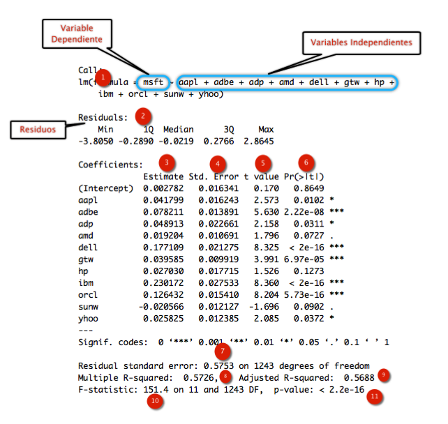

# Predicción

Los modelos de regresión tienen como una de sus objetivos predecir la variable dependiente.

$$\begin{gathered}
{{\hat y}_f} = {{\hat \beta }_1} + {{\hat \beta }_2} \cdot {{\hat x}_{2f}} + \cdots + {{\hat \beta }_k} \cdot {{\hat x}_{kf}} \hfill \\
f = Horizonte\,\,de\,\,{\text{Predicción}} \hfill \\
\end{gathered}$$

# Modelos No lineales

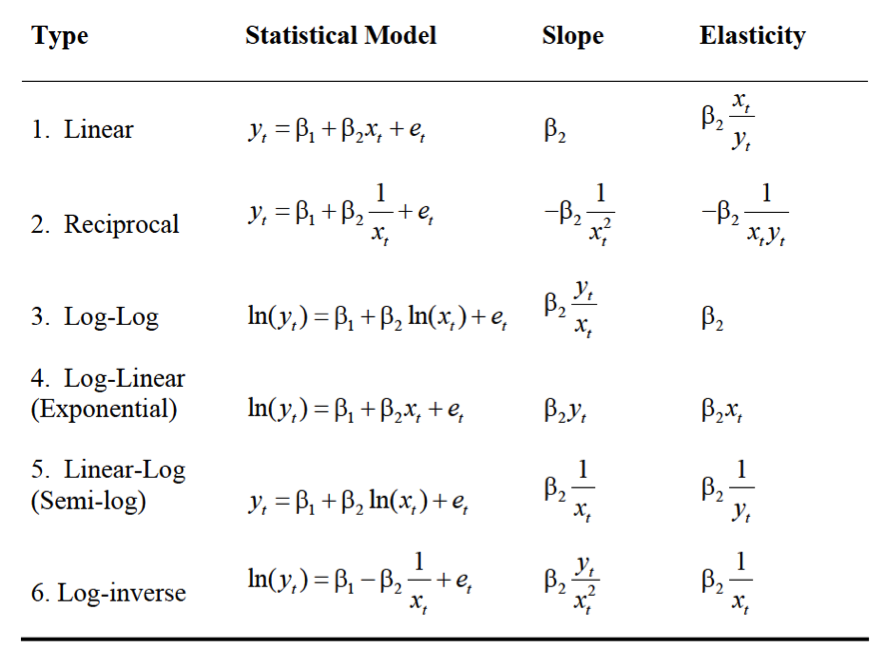

# Regresión y `R`

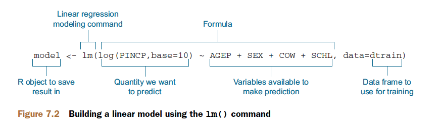

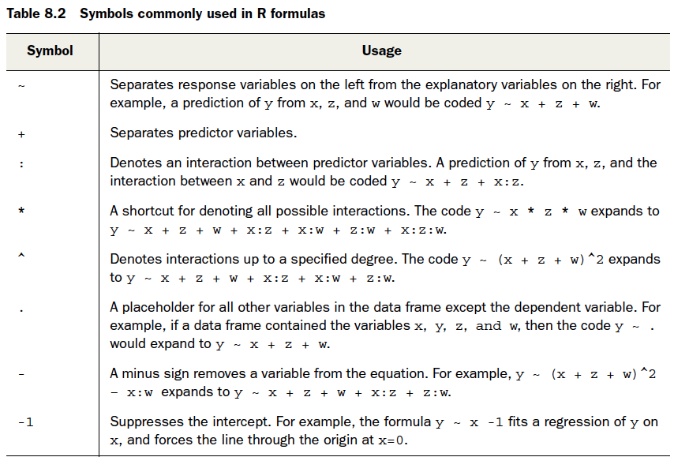

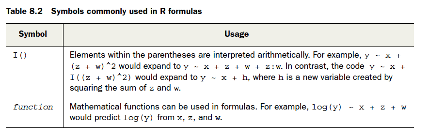

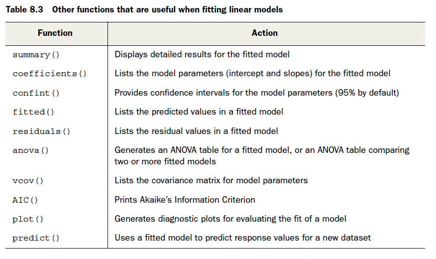

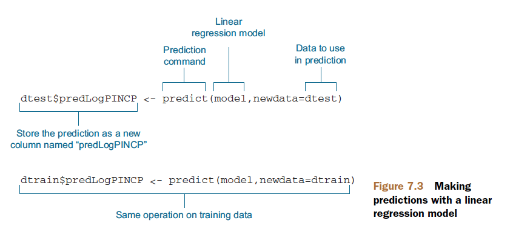

# Diagnosis

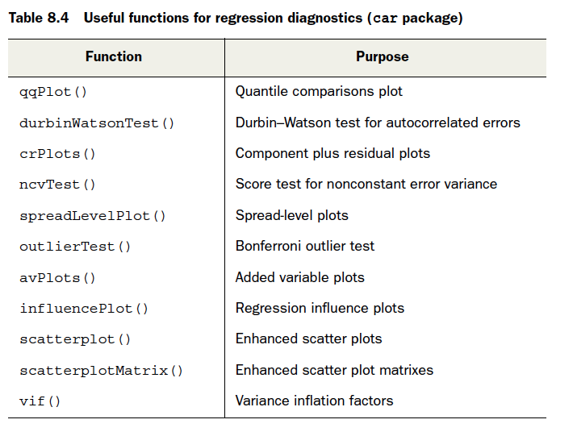

- Normalidad
- qqplot
- Histograma + densidad + normal + rug
- Jarque Bera
- Shapiro-wilks
- Linealidad -Componentes o Graifocs de residuos parciales
- Varianza Constante. Homocedasticidad
- Varianza no constante (ncvtest)
- Breusch-Pagan
- White
- Validación Global
- Multicolinealidad
- Factor de inflación de varianza (VIF)
- Observaciones anómalas
- Atípicos
- Extrema o Apalancada
- Influyente

Una observación es atípica si el residuo asociado es grande.

Una observación es extrema (o potencialmente influyente o apalancada) si se encuentra apreciablemente alejada del resto de observacines de la muestra.

Una observación influyente si la presencia de dicha observación en la muestra altera significativamente algún aspecto de la estimación del modelo.